# Reproducible Research: Peer Assessment 1

B. Bansenauer

## What is mean total number of steps taken per day?

```r
df.stepsperday<-ddply(df, .(date), summarize, total= sum(steps))
mean(na.omit(df.stepsperday$total))
```

```
## [1] 10766.19
```

```r
median(na.omit(df.stepsperday$total))
```

```
## [1] 10765
```

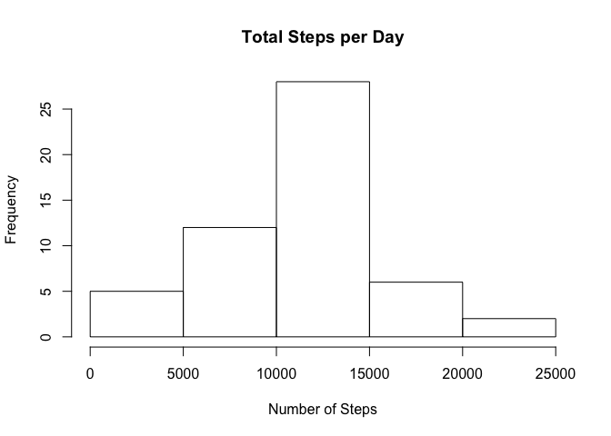

```r
hist(df.stepsperday$total,
     main="Total Steps per Day",
     xlab= "Number of Steps")
```

## What is the average daily activity pattern?

Plot the average number of steps taken across all days during each 5-minute interval.

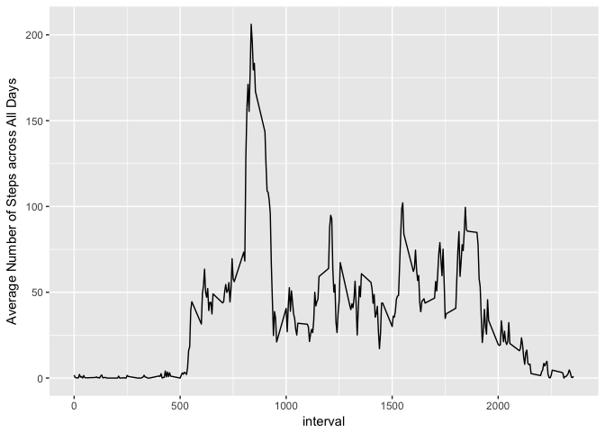

```r
df.intervals<-ddply(df, .(interval), summarize, mean=mean(na.omit(steps)))
ggplot(df.intervals, aes(interval, mean))+geom_line()+ylab("Average Number of Steps across All Days")
```

Investigate which 5-minute interval, on average across all the days in the dataset, contains the maximum number of steps?

```r
df.intervalMax<-subset(df.intervals, mean==max(df.intervals$mean, na.rm = TRUE))
```

**Interval 835 contains the maximum average steps of 206.1698113.**

## Inputing missing values

1. Calculate and report the total number of missing values in the dataset (i.e. the total number of rows with NAs)

```r
count(is.na(df))
```

```
##   x.steps x.date x.interval  freq
## 1   FALSE  FALSE      FALSE 15264
## 2    TRUE  FALSE      FALSE  2304
```

3. Create a new dataset that is equal to the original dataset but with the missing step data filled in with the 5-minute interval mean (rounded).

```r
df.intervalstack<-rep(df.intervals$mean,61)
df.na<-is.na(df$steps)
df.filled<-df
df.filled$steps[df.na]<-round(df.intervalstack[df.na])
```

4. Make a histogram of the total number of steps taken each day and calculate and report the mean and median total number of steps taken per day.

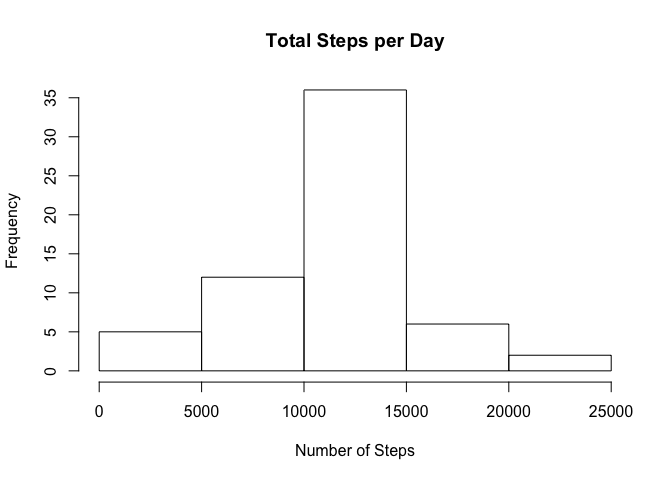

```r
df.stepsperday.filled<-ddply(df.filled, .(date), summarize, total= sum(steps))
hist(df.stepsperday.filled$total,
     main="Total Steps per Day",
     xlab= "Number of Steps")
```

**The total number of steps per day using the filled dataset shows a slightly lower mean and median:**

```r
mean(df.stepsperday.filled$total)
```

```
## [1] 10765.64
```

```r
median(df.stepsperday.filled$total)
```

```
## [1] 10762
```

## Are there differences in activity patterns between weekdays and weekends?

1. Create a new factor variable in the dataset with two levels – “weekday” and “weekend” indicating whether a given date is a weekday or weekend day.

```r
df2 <- mutate(df.filled, day = factor(case_when(weekdays(as.Date(date),abbreviate=TRUE) %in% c("Sat", "Sun") ~ "weekend",  TRUE ~ "weekday")))
summary(df2)
```

```
##      steps                date          interval           day
##  Min.   :  0.00   2012-10-01:  288   Min.   :   0.0   weekday:12960
##  1st Qu.:  0.00   2012-10-02:  288   1st Qu.: 588.8   weekend: 4608
##  Median :  0.00   2012-10-03:  288   Median :1177.5
##  Mean   : 37.38   2012-10-04:  288   Mean   :1177.5
##  3rd Qu.: 27.00   2012-10-05:  288   3rd Qu.:1766.2
##  Max.   :806.00   2012-10-06:  288   Max.   :2355.0
##                   (Other)   :15840
```

2. Make a panel plot containing a time series plot (i.e. type = “l”) of the 5-minute interval (x-axis) and the average number of steps taken, averaged across all weekdays or weekend days (y-axis).

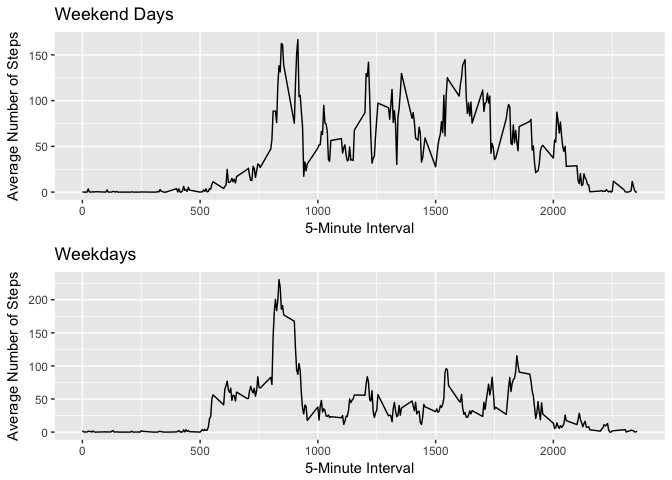

```r
df2.weekday.intervals<-ddply(subset(df2, day=="weekday"), .(interval), summarize, mean=mean(steps))
df2.weekend.intervals<-ddply(subset(df2, day=="weekend"), .(interval), summarize, mean=mean(steps))
p1<-ggplot(df2.weekday.intervals, aes(interval, mean))+geom_line()+labs(title = "Weekdays",  x="5-Minute Interval", y = "Average Number of Steps")
p2<-ggplot(df2.weekend.intervals, aes(interval, mean))+geom_line()+labs(title= "Weekend Days", x="5-Minute Interval", y = "Average Number of Steps")
g1 <- ggplotGrob(p1)
g2 <- ggplotGrob(p2)
g <- rbind(g2, g1, size = "first")
g$widths <- g1$widths
grid.newpage()
grid.draw(g)
```